# Lab 7: Directional $t$-tests

Course activity

STAT218

This lab has two objectives:

1. Learn to use the `t.test(...)` function
2. Learn to discern the appropriate direction for a $t$ test

We’ll use two familiar datasets: body temperature and heart rate measurements for 39 individuals; and data on birth weights and weeks at birth for a sample of 100 births in North Carolina in 2004.

```r
library(tidyverse)
load('data/temps.RData')
load('data/nhanes.RData')
ncbirths <- read_csv('data/ncbirths.csv')
```

### The `t.test(...)` function

The `t.test(...)` function produces both a hypothesis test and an confidence interval, and can be used to obtain either or both in practice.

Let’s demonstrate with the practice problem you completed most recently: inference on the mean nightly hours of sleep among U.S. adults based on NHANES data.

The default behavior of `t.test(...)` if given no arguments besides a vector of data is to test $H_0: \mu = 0$ against a two-sided alternative ($H_A: \mu \neq 0$) and provide a 95% confidence interval. There are three key arguments that allow you to adjust this behavior:

- `mu = ...` adjusts the value for the mean in the null hypothesis $H_0$
  - default `mu = 0`
- `alternative = ...` adjusts the direction of the alternative, with options
  - `'less'` for a lower-sided alternative
  - `'greater'` for an upper-sided alternative
  - `'two.sided'` (default) for a two-sided alternative
- `conf.level = ...` adjusts the confidence level for the interval estimate
  - default `conf.level = 0.95`

The examples below illustrate this usage. Run each command and **look at the output closely to determine what changes**.

```r
# extract sleep variable
sleep <- nhanes$sleephrsnight

# default behavior (these are equivalent)
t.test(sleep)
```

```
    One Sample t-test

data:  sleep
t = 284.36, df = 3178, p-value < 2.2e-16
alternative hypothesis: true mean is not equal to 0
95 percent confidence interval:
 6.911123 7.007090
sample estimates:
mean of x
 6.959107
```

```r
t.test(sleep, mu = 0, alternative = 'two.sided', conf.level = 0.95)
```

```
    One Sample t-test

data:  sleep
t = 284.36, df = 3178, p-value < 2.2e-16
alternative hypothesis: true mean is not equal to 0
95 percent confidence interval:
 6.911123 7.007090
sample estimates:
mean of x
 6.959107
```

```r
# change null value to 7 hours of sleep
t.test(sleep, mu = 7, alternative = 'two.sided', conf.level = 0.95)
```

```
    One Sample t-test

data:  sleep
t = -1.671, df = 3178, p-value = 0.09482
alternative hypothesis: true mean is not equal to 7
95 percent confidence interval:
 6.911123 7.007090
sample estimates:
mean of x
 6.959107
```

```r
# change the confidence level
t.test(sleep, mu = 7, alternative = 'two.sided', conf.level = 0.99)
```

```
    One Sample t-test

data:  sleep
t = -1.671, df = 3178, p-value = 0.09482
alternative hypothesis: true mean is not equal to 7
99 percent confidence interval:
 6.896032 7.022182
sample estimates:
mean of x
 6.959107
```

```r
# change the direction of the alternative
t.test(sleep, mu = 7, alternative = 'less', conf.level = 0.99)
```

```
    One Sample t-test

data:  sleep
t = -1.671, df = 3178, p-value = 0.04741
alternative hypothesis: true mean is less than 7
99 percent confidence interval:
     -Inf 7.016067
sample estimates:
mean of x
 6.959107
```

Focus for a moment on the last example. In detail, this tests, at the 1% significance level, the hypotheses:

$$\begin{cases}
H_0: &\mu = 7 \\
H_A: &\mu < 7
\end{cases}$$

In general, it’s important to set the confidence level to correspond to the significance level of the test you wish to perform, so that the test interpretation and interval provided match.

**Your turn 1**

Adjust the arguments of the `t.test(...)` function to achieve the following:

- find a 90% CI for the mean
- test whether mean sleep is 6.9 at the 5% level
- test whether mean sleep is 6.9 at the 1% level
- test whether mean sleep exceeds 6.9 at the 5% level
- test whether mean sleep exceeds 6.9 at the 1% level

```r
# obtain a 90% confidence interval for the mean hours of sleep

# test whether mean sleep is 6.9 at the 5% level

# test whether mean sleep is 6.9 at the 1% level

# test whether mean sleep exceeds 6.9 at the 5% level

# test whether mean sleep exceeds 6.9 at the 1% level
```

For extra practice, write a short interpretation of the results of each test following the style introduced in class.

### Distinguishing directional alternatives

Here we’ll use the temperature/heartrate data to illustrate a variety of directional tests based on questions of interest.

As you’re looking over the examples, focus on the correspondence between the questions and the direction of the alternative.

```r
# extract body temperature variable
bodytemps <- temps$body.temp

# is mean temperature different from 98.6 at the 5% significance level?
t.test(bodytemps, mu = 98.6, alternative = 'two.sided', conf.level = 0.95)

# is mean temperature less than 98.6 at the 5% significance level?
t.test(bodytemps, mu = 98.6, alternative = 'less', conf.level = 0.95)

# is mean temperature greater than 98.1 at the 5% significance level?
t.test(bodytemps, mu = 98.1, alternative = 'greater', conf.level = 0.95)

# is mean temperature greater than 98.1 at the 1% significance level?
t.test(bodytemps, mu = 98.1, alternative = 'greater', conf.level = 0.99)

# is mean temperature less than 98.9 at the 5% significance level?
t.test(bodytemps, mu = 98.9, alternative = 'less', conf.level = 0.95)
```

As an aside (but an important one!), performing all of these tests together is only meant to illustrate how the function works, **not how to perform an analysis**. Trying out many tests until you obtain significant results is known as “$p$ hacking”, and is not an acceptable practice.

**Your turn 2**

Using the `heart.rate` variable, test the following hypotheses:

- Is mean heart rate 65bpm at the 5% level?
- Is mean heart rate 70bpm at the 1% level?
- Is mean heart rate greater than 70bpm at the 1% level?
- Is mean heart rate less than 75bpm at the 10% level?
- Is mean heart rate greater than 75bpm at the 10% level?

```r
# extract heart rate variable

# is mean heart rate 65bpm at the 5% level?

# is mean heart rate 70bpm at the 1% level?

# is mean heart rate greater than 70bpm at the 1% level?

# is mean heart rate less than 75bpm at the 10% level?

# is mean heart rate greater than 75bpm at the 10% level?
```

### A brief analysis

Now that you’re familiar with using the `t.test(...)` function, let’s do something a bit more realistic. Suppose that, using the `ncbirths` data, you want to perform inference on the number of weeks at birth. We’re told that 40 weeks is typical.

#### Advance decisions

In advance of looking at the data (or perhaps even having data) we should determine:

1. the hypotheses to test
2. the level at which we’ll perform the test

To make these choices, first note that there’s no obvious directional question to ask here. So, we’ll test whether the mean number of weeks at birth is 40. A 5% significance level is conventional, so we’ll stick with that.

#### Assessing assumptions

Before going ahead, let’s inspect the data.

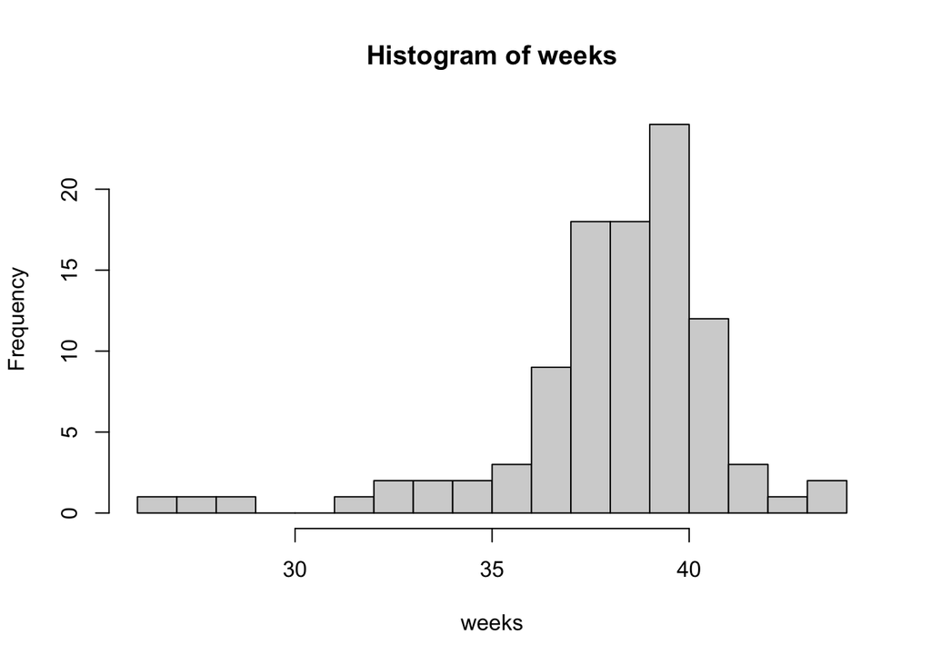

```r
# extract variable of interest
weeks <- ncbirths$weeks

# inspect distribution
hist(weeks, breaks = 15)
```

This is an interesting case, because we do have a left-skewed distribution *and* there are a few outliers below 30 weeks. However, the sample size is large ($n = 100$), so the test should still work well regardless.

#### Performing the test

For inference we’ll want to report a test result and interval estimate. Both of these are obtained using `t.test(...)` as above, but of course we only perform *one* test/interval calculation.

```r
# inference
t.test(weeks, mu = 40, alternative = 'two.sided', conf.level = 0.95)
```

```
    One Sample t-test

data:  weeks
t = -5.0421, df = 99, p-value = 2.084e-06
alternative hypothesis: true mean is not equal to 40
95 percent confidence interval:
 37.97938 39.12062
sample estimates:
mean of x
    38.55
```

Take a moment to inspect the results.

#### Interpreting results

Following the format in class, a report of the results should interpret the test and interval in context, providing supporting statistics parenthetically:

> Data from North Carolina in 2004 provide strong evidence that the mean number of weeks at birth differs from 40 (*T* = -5.0421 on 99 degrees of freedom, *p* < 0.0001). With 95% confidence, the mean number of weeks at birth is estimated to be between 37.98 and 39.12 weeks, with a point estimate of 38.55 weeks (SE 0.289).